# Diamonds Price Estimation

Assignment 3

In this assignment, `diamonds` dataset in ggplot2 package is used for exploratory analysis and price prediction using CART model. Plots demonstrating relationship between variables and some insights about response variable `price` are received in exploratory data analysis part. Then, Principal Component Analysis, PCA, is made to reduce dimensionality of the dataset and determine principal components which are used in CART model. After getting predicted prices for test data, the model is evaluated with Rsquared and objective function value of the CART model.

# 1 Package Loading

```r
library(tidyverse) #For data manipulation
library(rpart) #To construct CART models
library(rpart.plot) # It also includes titanic data
library(rattle) #For visualization
library(FactoMineR)
library(ggplot2)
library(corrplot)
```

# 2 Preprocessing Data

```r
set.seed(503)

diamonds_test <- diamonds %>% mutate(diamond_id = row_number()) %>%
  group_by(cut, color, clarity) %>% sample_frac(0.2) %>% ungroup()%>%
  filter(complete.cases(.))  #Remove all NA including rows


diamonds_train <- anti_join(diamonds %>% mutate(diamond_id = row_number()),
                            diamonds_test, by = "diamond_id")%>%
  filter(complete.cases(.))  #Remove all NA including rows
```

`NA` values in train and test data are eliminated to increase the quality of data.

# 3 Explanatory Data Analysis

## 3.1 Distribution of Some Variables

Distributions of `price`, `carat`, `cut` variables are examined here.

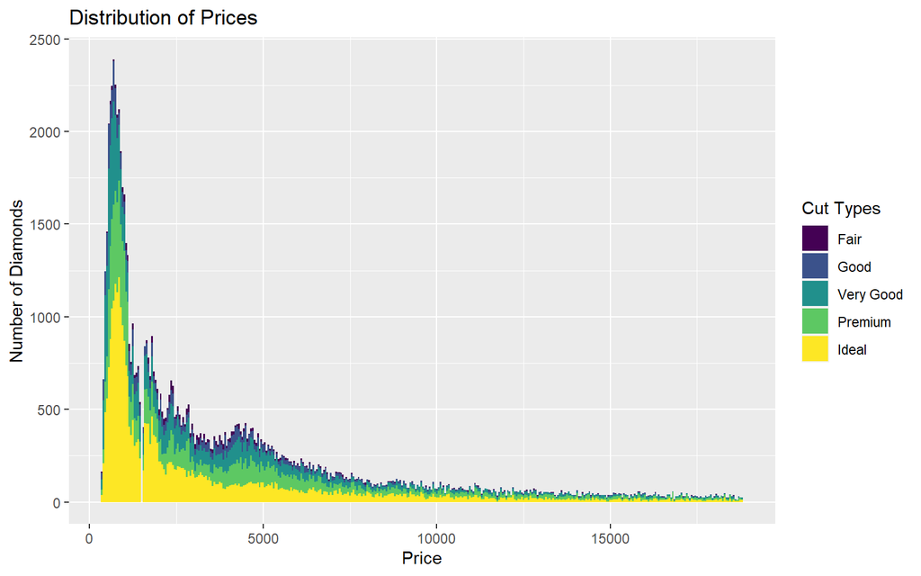

```r
diamonds_all <- rbind(diamonds_train, diamonds_train)

##price######
ggplot(diamonds_all,aes(x=price,fill=cut))+geom_histogram(binwidth=50)+
  labs(y="Number of Diamonds", x="Price",fill="Cut Types",title="Distribution of Prices")
```

- Number of diamonds peaks on certain carat levels. Diamonds are mostly concentrated at carat level 0.3 and 0.7 an 1.0.

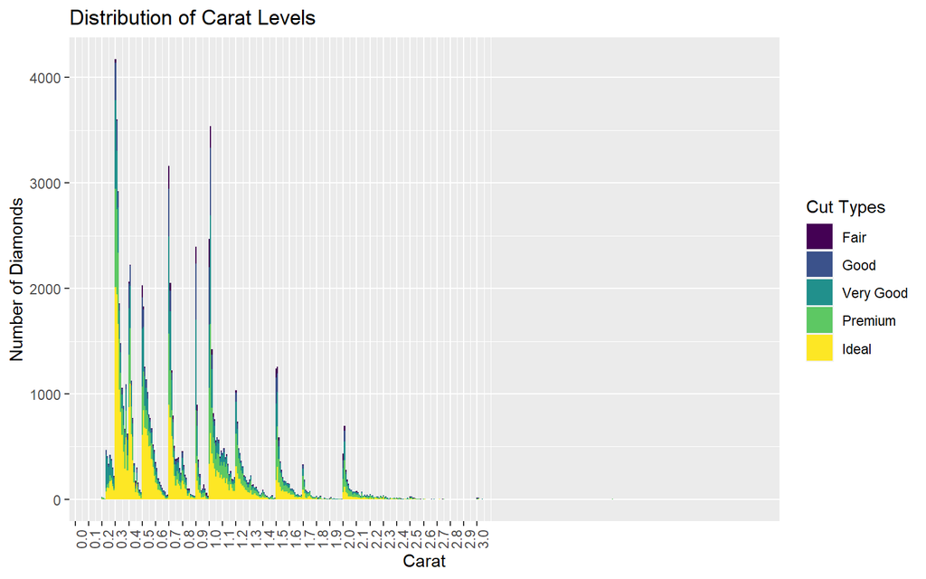

```r
ggplot(diamonds_all,aes(x=carat,fill=cut))+geom_histogram(binwidth = 0.01)+
  scale_x_continuous(breaks = seq(from = 0, to = 3, by = 0.1))+
  theme(axis.text.x = element_text(angle = 90))+
  labs(y="Number of Diamonds",x="Carat",fill="Cut Types", title="Distribution of Carat Levels")
```

- Here is the price distribution by cut types. Minimum mean value belongs to `Ideal` cut type.

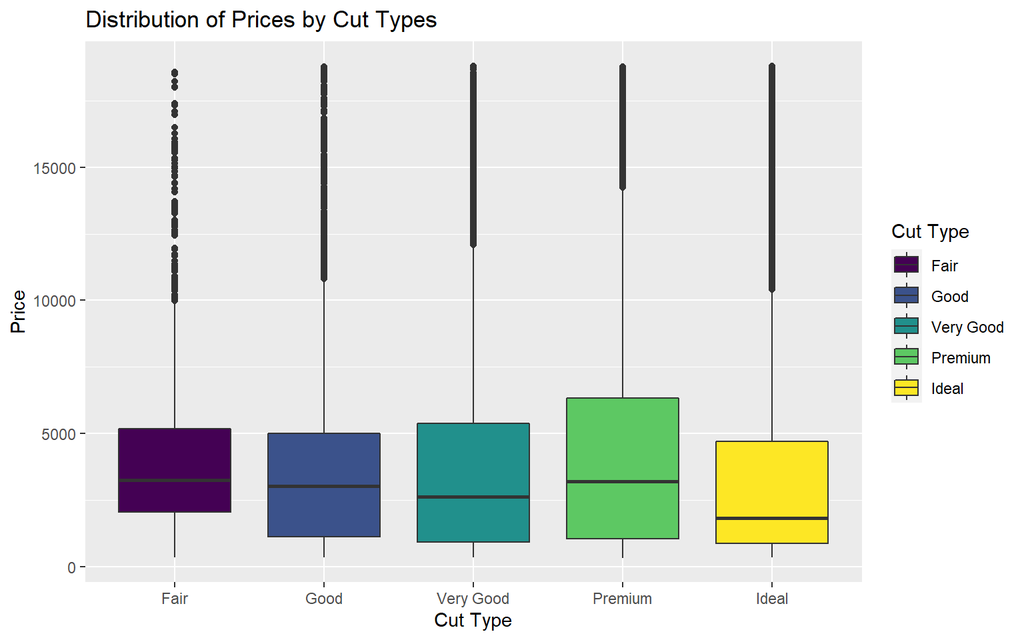

```r
ggplot(diamonds_all,aes(x=cut, y=price, fill=cut))+geom_boxplot()+
  labs(fill="Cut Type", y="Price",x="Cut Type", title="Distribution of Prices by Cut Types")
```

- The distribution of the frequency of cut types is given with percentage rates in the pie chart.

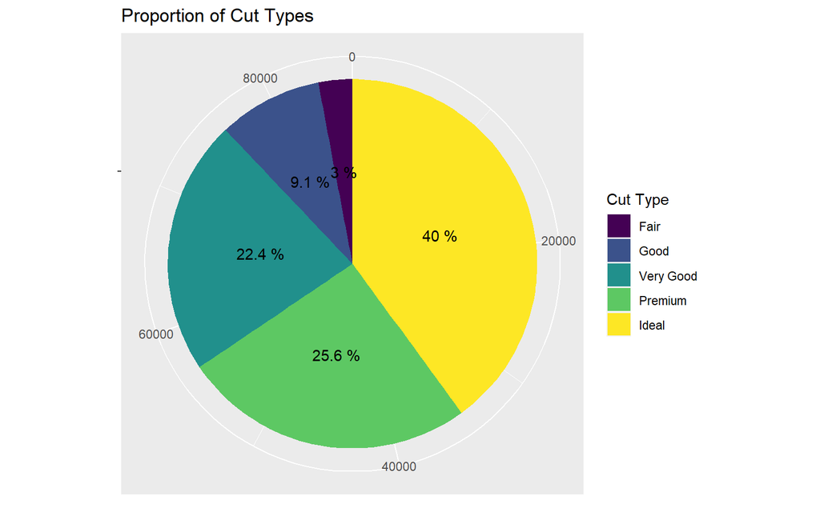

```r
diamonds_all%>%
  group_by(cut)%>%
  tally()%>%
  arrange(desc(n))%>%
  head(10)%>%
  ggplot(., aes (x="", y = n, fill = cut)) +
  geom_bar(width = 1, stat = "identity") +
  geom_text(aes(label = paste(round(n / sum(n) * 100, 1), "%")),
            position = position_stack(vjust = 0.5))+
  coord_polar("y")+
  labs(fill = "Cut Type",
       x = NULL,
       y = NULL,
       title = "Proportion of Cut Types")+
  theme(axis.line = element_blank())
```

## 3.2 Correlation between Variables

Correlation plot of variables is essential to see effects of variables on the response variable before constructing a model. All numerical variables can be inputs to correlation plot. In the first plot, less correlated variables are also plotted, but they are eliminated in the second plot to see the most explanatory variables.

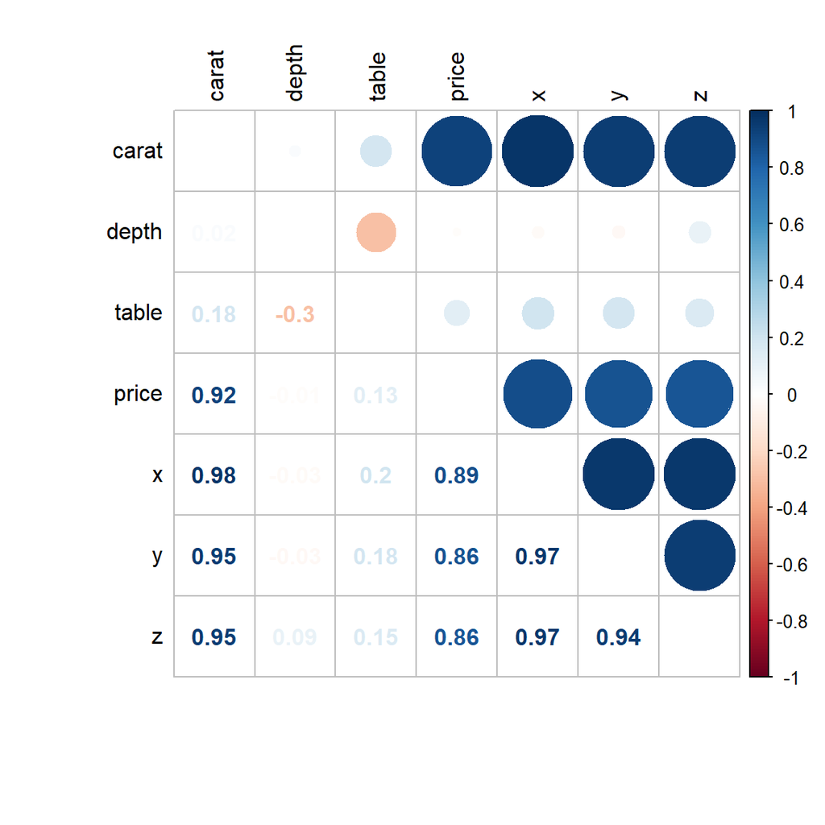

```r
#correlations of all numeric variables
cor_numVar <- cor(diamonds_all[,c(1,5,6,7,8,9,10)], use="pairwise.complete.obs")

corrplot.mixed(cor_numVar, tl.col="black", tl.pos = "lt")
```

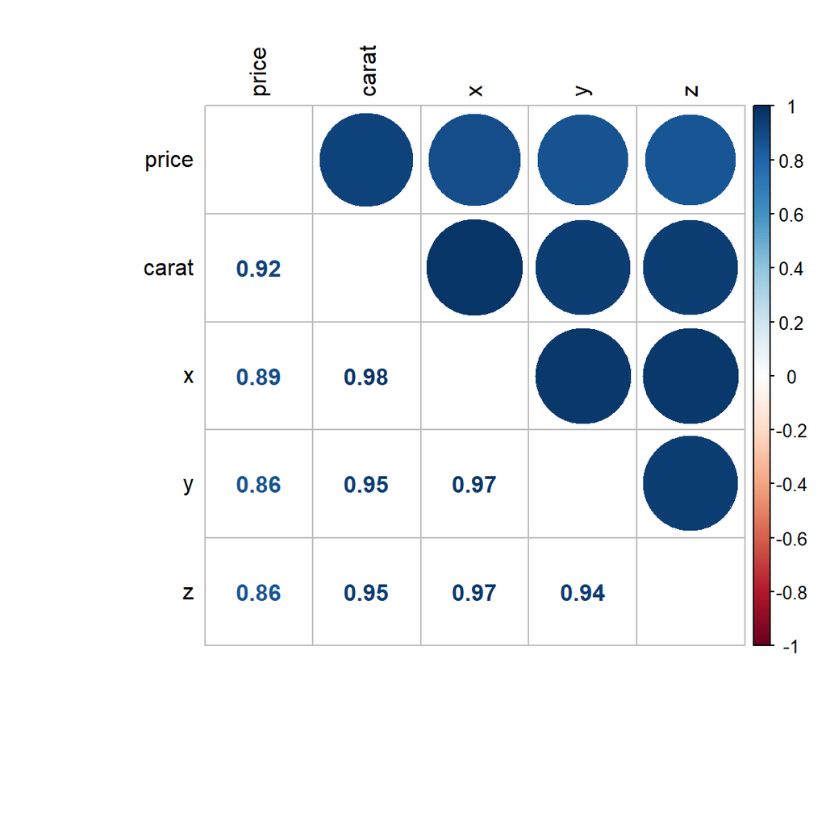

```r
cor_sorted <- as.matrix(sort(cor_numVar[,'price'], decreasing = TRUE))
#select only high corelations
CorHigh <- names(which(apply(cor_sorted, 1, function(x) abs(x)>0.5)))
cor_numVar_high <- cor_numVar[CorHigh, CorHigh]

corrplot.mixed(cor_numVar_high, tl.col="black", tl.pos = "lt")
```

Now, it is possible to say the most correlated variables are `carat`, `x`, `y` and `z`.

## 3.3 Relationship between Price and the Most Correlated Variables

Now that the most correlated variables are found, it is useful to see how their behaviors change when the response variable changes.

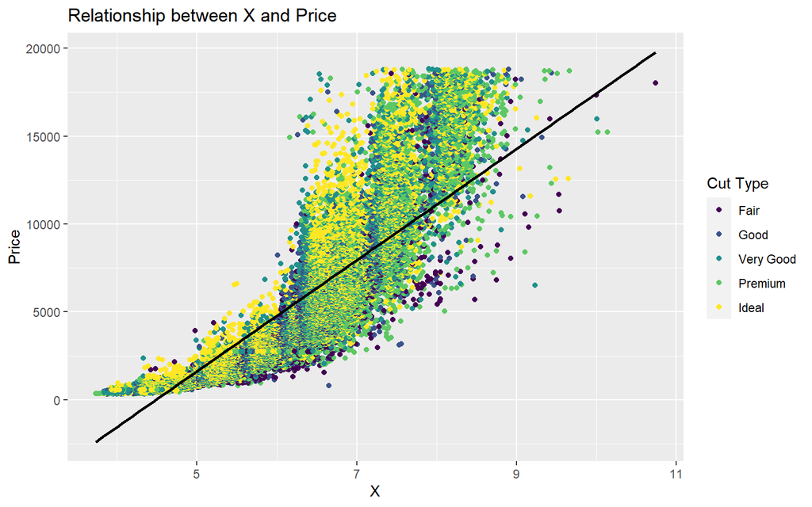

```r
diamonds_all%>%
  filter(x>3)%>%
  ggplot(.,aes(x=x, y=price, color=cut))+geom_point()+geom_smooth(method = "lm", se=FALSE, color="black", aes(group=1))+
    labs(x="X",y="Price",color="Cut Type",title="Relationship between X and Price")
```

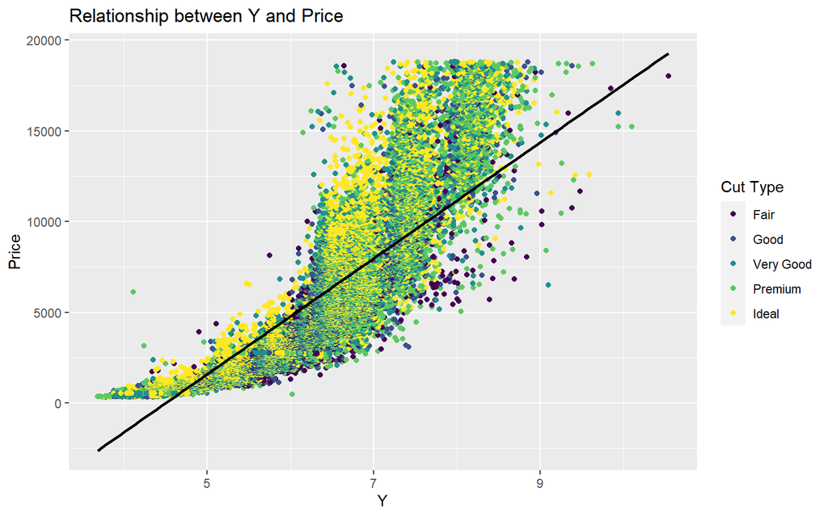

```r
diamonds_all%>%
  filter(y<20 & y>2)%>%
  ggplot(.,aes(x=y, y=price, color=cut))+geom_point()+geom_smooth(method = "lm", se=FALSE, color="black", aes(group=1))+
    labs(x="Y",y="Price",color="Cut Type",title="Relationship between Y and Price")
```

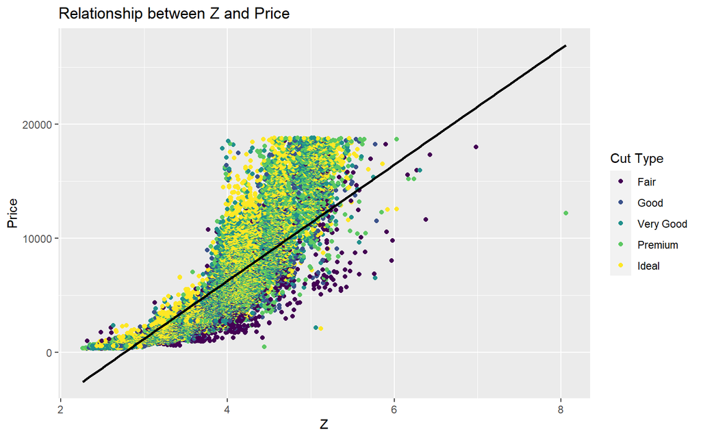

```r
diamonds_all%>%
  filter(z<20 & z>2)%>%
  ggplot(.,aes(x=z, y=price, color=cut))+geom_point()+geom_smooth(method = "lm", se=FALSE, color="black", aes(group=1))+
    labs(x="Z",y="Price",color="Cut Type",title="Relationship between Z and Price")
```

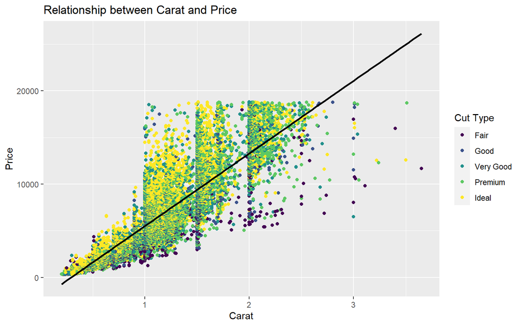

```r
diamonds_all%>%
  filter(carat<4)%>%
  ggplot(.,aes(x=carat, y=price, color=cut))+geom_point()+geom_smooth(method = "lm", se=FALSE, color="black", aes(group=1))+
  labs(x="Carat",y="Price",color="Cut Type",title="Relationship between Carat and Price")
```

# 4 Machine Learning

In this part, PCA is made to compute principal components in order to use them when constructing CART model. Evaluation of the model is also made with predicted prices on test data using some metrics.

## 4.1 Principle Component Analysis(PCA)

Correlation values for numerical variables should be checked to see if there is a need for dimensionality reduction.

```r
cor(diamonds_train[,c(1,5,6,8,9,10)])
```

```
##            carat       depth      table           x           y          z
## carat 1.00000000  0.02457809  0.1837469  0.97572577  0.94707234 0.94940570
## depth 0.02457809  1.00000000 -0.2981340 -0.02898875 -0.03291973 0.09109925
## table 0.18374688 -0.29813400  1.0000000  0.19765100  0.18453984 0.15169959
## x     0.97572577 -0.02898875  0.1976510  1.00000000  0.96904818 0.96615669
## y     0.94707234 -0.03291973  0.1845398  0.96904818  1.00000000 0.94323399
## z     0.94940570  0.09109925  0.1516996  0.96615669  0.94323399 1.00000000
```

It is clear that `carat` is higly correlated with `x`, `y`, and `z`. Also, `x`, `y`, and `z` are correlated with each other with more than 90 percent. So, we need to reduce dimensionality of data with PCA.

```r
pca_train <- princomp(as.matrix(diamonds_train[,c(1,5,6,8,9,10)]),cor=T)

pca_test<-princomp(as.matrix(diamonds_test[,c(1,5,6,8,9,10)]),cor=T)

summary(pca_train,loadings=TRUE)
```

```
## Importance of components:
##                          Comp.1    Comp.2    Comp.3    Comp.4      Comp.5
## Standard deviation     1.979800 1.1336225 0.8255050 0.2273068 0.218071172
## Proportion of Variance 0.653268 0.2141833 0.1135764 0.0086114 0.007925839
## Cumulative Proportion  0.653268 0.8674513 0.9810277 0.9896391 0.997564967
##                             Comp.6
## Standard deviation     0.120872645
## Proportion of Variance 0.002435033
## Cumulative Proportion  1.000000000
##
## Loadings:
##       Comp.1 Comp.2 Comp.3 Comp.4 Comp.5 Comp.6
## carat  0.496                0.638  0.442  0.385
## depth         0.734 -0.671
## table  0.122 -0.669 -0.733
## x      0.501                0.114        -0.855
## y      0.494               -0.760  0.361  0.201
## z      0.493  0.103               -0.817  0.279
```

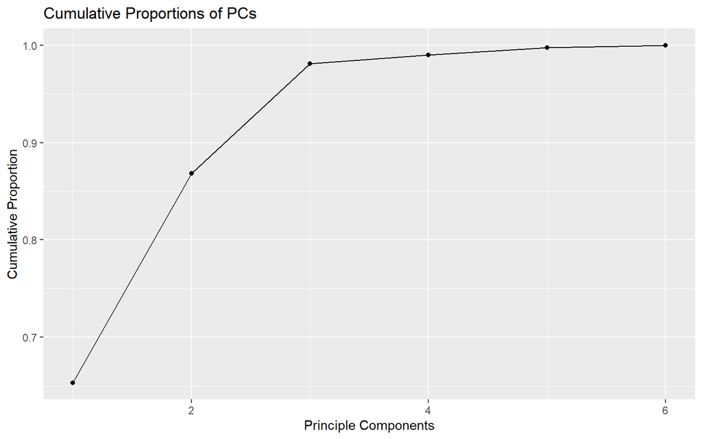

```r
ggplot(data.frame(pc=1:6,cum_var=c(0.6534323 ,0.8681295 ,0.9811491 ,0.989797745 ,
                                   0.997600442 ,1.000000000
)),aes(x=pc,y=cum_var)) + geom_point() + geom_line()+
  labs(y="Cumulative Proportion",x="Principle Components",title="Cumulative Proportions of PCs")
```

Principle components are calculated with princomp() function. It is possible to say the first 2 PC is responsible for 86.8% of the variation. First PC considers all variables except `depth` as a positive effect, second PC is highly affected by `depth` and considers `table` as a negative effect. With the third PC, 98% of the variation is explained.

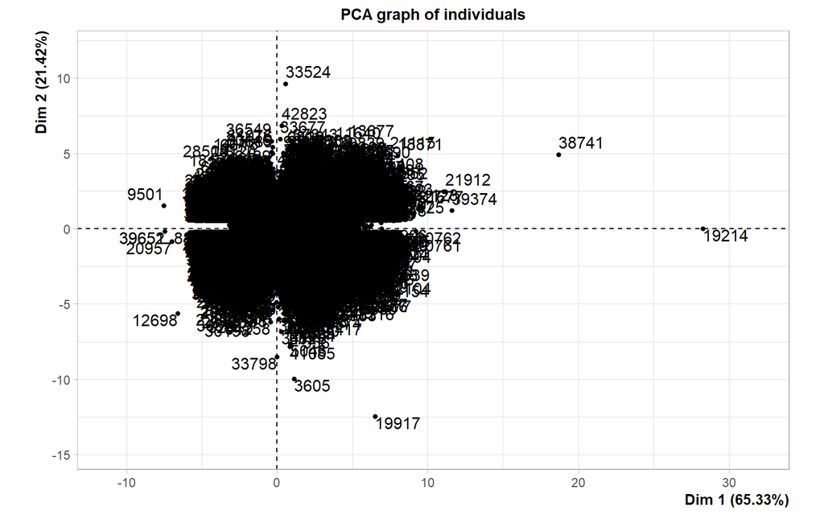

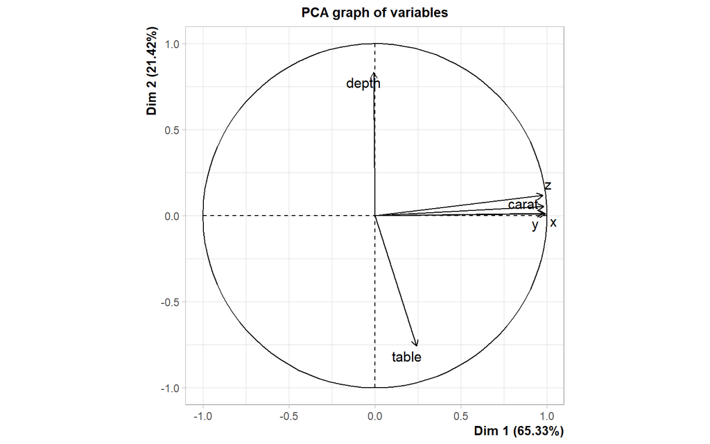

```r
data_pca_train<-cbind(diamonds_train,pca_train$scores[,1:2])
data_pca_test<-cbind(diamonds_test,pca_test$scores[,1:2])

#Kaiser
diamonds_PCA<-PCA(diamonds_train[,c(1,5,6,8,9,10)])
```

```r
diamonds_PCA$eig
```

```
##        eigenvalue percentage of variance cumulative percentage of variance
## comp 1 3.91960789             65.3267982                          65.32680
## comp 2 1.28509997             21.4183328                          86.74513
## comp 3 0.68145851             11.3576418                          98.10277
## comp 4 0.05166840              0.8611400                          98.96391
## comp 5 0.04755504              0.7925839                          99.75650
## comp 6 0.01461020              0.2435033                         100.00000
```

The Kaiser-Guttman Rule can be applied to decide which principle components should be chosen. So, the principle components whose eigen values are more than 1 should be selected. These are first two principle components.

## 4.2 Constructing Model

Selected principle components are used as inputs in rpart() function to construct CART model using train data. The model can be demonstrated via fancyRpartPlot() returning the following tree:

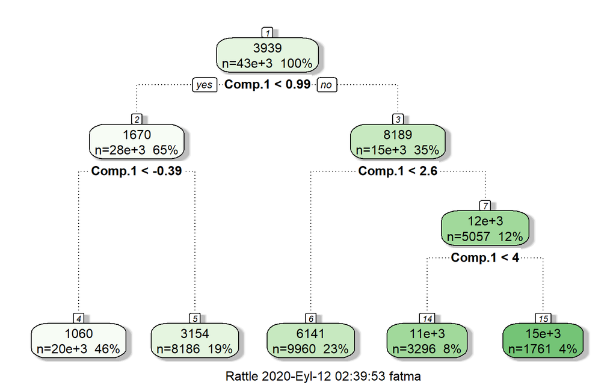

```r
diamonds_model <- rpart(price ~ Comp.1 + Comp.2, data=data_pca_train)
fancyRpartPlot(diamonds_model)
```

## 4.3 Prediction

Predicted prices are calculated with the model, but quality of the model depends on results with test data `data_pca_test`.

```r
diamonds_in_sample <- predict(diamonds_model)

print(head(diamonds_in_sample))
```

```
##        1        2        3        4        5        6
## 1060.285 1060.285 1060.285 1060.285 1060.285 1060.285
```

```r
diamonds_outof_sample <- predict(diamonds_model,newdata=data_pca_test)
print(head(diamonds_outof_sample))
```

```
##         1         2         3         4         5         6
## 10838.441  1060.285  6141.157  6141.157  3154.266  3154.266
```

## 4.4 Evaluating with Objective Function of CART Model

Error rate for regression trees is the squared distance (very similar to linear regression) of each item in the node to the average response $(\hat{Y}_k)$ value of the node. So, final objective function is:

$$min\sum_{k}^K(\displaystyle \min_{i \in G_k}(y_i-\hat{Y})^2)+\alpha|K|$$
Objective values are calculated for both test and train data. Since the model is trained with train data, objective value is higher for test data not surprisingly. However, price values are large numbers, so the objective value for test data can also be regarded as low and good result.

- Objective value for train data:

```r
objective_train<-data_pca_train%>%
  mutate(prediction=diamonds_in_sample)%>%
  group_by(prediction)%>%
  summarise(error=min((price-prediction)^2))

error_sum_train<-sum(objective_train$error)
error_sum_train
```

```
## [1] 0.6207577
```

- Objective value for test data:

```r
objective_test<-data_pca_test%>%
  mutate(prediction=diamonds_outof_sample)%>%
  group_by(prediction)%>%
  summarise(error=min((price-prediction)^2))

error_sum_test<-sum(objective_test$error)
error_sum_test
```

```
## [1] 158.2983
```

## 4.5 Evaluating with Rsquared

Rsquared values are used as evaluation metrics. Since the Rsquared values for both are high and close to 1, the model fits the data well.

- Rsquared value for train data:

```r
Rsquared_train<-data_pca_train%>%
  mutate(prediction=diamonds_in_sample, residual=(price-prediction)^2,
         square=(price-mean(price))^2)%>%
  summarise(RSS=sum(residual),SSt=sum(square),Rsquared=1-(RSS/SSt))
Rsquared_train
```

```
##            RSS          SSt  Rsquared
## 1 105814946650 689390322025 0.8465094
```

- Rsquared value for test data:

```r
Rsquared_test<-data_pca_test%>%
  mutate(prediction=diamonds_outof_sample, residual=(price-prediction)^2,
         square=(price-mean(price))^2)%>%
  summarise(RSS=sum(residual),SSt=sum(square),Rsquared=1-(RSS/SSt))
Rsquared_test
```

```
##           RSS         SSt  Rsquared
## 1 26173881241 1.69075e+11 0.8451937
```

As a result of the evaluation of the model, it is possible to say the model is successful. This result can also be improved by applying other types of model or dimensionality reduction methods on the data.

# 5 Data Source

- `diamonds` in ggplot2 package

# 6 Reference

- An Example of PCA: [Democrat Prediction using PCA Regression](https://www.kaggle.com/ricsam/democrat-prediction-using-pca-regression)
- Correlation Plot: [House Prices Analysis](https://www.kaggle.com/erikbruin/house-prices-lasso-xgboost-and-a-detailed-eda)
- [Mathematics in R Markdown](https://rpruim.github.io/s341/S19/from-class/MathinRmd.html)
- [Lecture Notes 1](https://mef-bda503.github.io/archive/fall17/files/intro_to_ml.html)
- [Lecture Notes 2](https://mef-bda503.github.io/archive/fall17/files/intro_to_ml_2.html)
- DataCamp Course: [Dimensionality Reduction in R](https://learn.datacamp.com/courses/dimensionality-reduction-in-r)